# BIB Revision — Supplementary Analysis

# EOPE — Placentation (T1) (Fig 4B, cx)

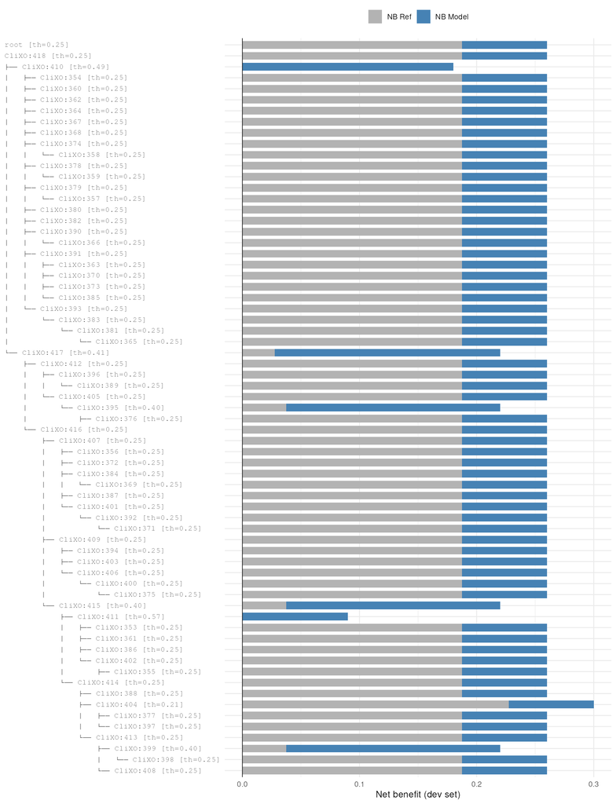

**Figure 15.** Net benefit of model vs. reference at selected thresholds — EOPE — Placentation (T1) (Fig 4B, cx).